# PSYC6841 - Session 3 Homework - Jaclyn Spangler

# File Setup

## Libraries

### Helper functions

```r
#From Matt Dancho DS4B 201
plot_hist_facet <- function(data, fct_reorder = FALSE, fct_rev = FALSE,
                            bins = 10, fill = palette_light()[[3]], color = "white", ncol = 5, scale = "free") {

    data_factored <- data %>%
        mutate_if(is.character, as.factor) %>%
        mutate_if(is.factor, as.numeric) %>%
        gather(key = key, value = value, factor_key = TRUE)

    if (fct_reorder) {
        data_factored <- data_factored %>%
            mutate(key = as.character(key) %>% as.factor())
    }

    if (fct_rev) {
        data_factored <- data_factored %>%
            mutate(key = fct_rev(key))
    }

    g <- data_factored %>%
        ggplot(aes(x = value, group = key)) +
        geom_histogram(bins = bins, fill = fill, color = color) +
        facet_wrap(~ key, ncol = ncol, scale = scale) +
        theme_tq()

    return(g)

}
```

## Loading Data

IBM HR Attrition Data

```r
library(readxl)
Data <- read_excel("C:/Users/Jaclyn/Desktop/LearningR/AdvAnalytics/00_data/WA_Fn-UseC_-HR-Employee-Attrition.xlsx")
colnames(Data)
```

```
 [1] "Age"                      "Attrition"
 [3] "BusinessTravel"           "DailyRate"
 [5] "Department"               "DistanceFromHome"
 [7] "Education"                "EducationField"
 [9] "EmployeeCount"            "EmployeeNumber"
[11] "EnvironmentSatisfaction"  "Gender"
[13] "HourlyRate"               "JobInvolvement"
[15] "JobLevel"                 "JobRole"
[17] "JobSatisfaction"          "MaritalStatus"
[19] "MonthlyIncome"            "MonthlyRate"
[21] "NumCompaniesWorked"       "Over18"
[23] "OverTime"                 "PercentSalaryHike"
[25] "PerformanceRating"        "RelationshipSatisfaction"
[27] "StandardHours"            "StockOptionLevel"
[29] "TotalWorkingYears"        "TrainingTimesLastYear"
[31] "WorkLifeBalance"          "YearsAtCompany"
[33] "YearsInCurrentRole"       "YearsSinceLastPromotion"
[35] "YearsWithCurrManager"
```

```r
str(Data)
```

```
tibble [1,470 x 35] (S3: tbl_df/tbl/data.frame)
 $ Age                     : num [1:1470] 41 49 37 33 27 32 59 30 38 36 ...
 $ Attrition               : chr [1:1470] "Yes" "No" "Yes" "No" ...
 $ BusinessTravel          : chr [1:1470] "Travel_Rarely" "Travel_Frequently" "Travel_Rarely" "Travel_Frequently" ...
 $ DailyRate               : num [1:1470] 1102 279 1373 1392 591 ...
 $ Department              : chr [1:1470] "Sales" "Research & Development" "Research & Development" "Research & Development" ...
 $ DistanceFromHome        : num [1:1470] 1 8 2 3 2 2 3 24 23 27 ...
 $ Education               : num [1:1470] 2 1 2 4 1 2 3 1 3 3 ...
 $ EducationField          : chr [1:1470] "Life Sciences" "Life Sciences" "Other" "Life Sciences" ...
 $ EmployeeCount           : num [1:1470] 1 1 1 1 1 1 1 1 1 1 ...
 $ EmployeeNumber          : num [1:1470] 1 2 4 5 7 8 10 11 12 13 ...
 $ EnvironmentSatisfaction : num [1:1470] 2 3 4 4 1 4 3 4 4 3 ...
 $ Gender                  : chr [1:1470] "Female" "Male" "Male" "Female" ...
 $ HourlyRate              : num [1:1470] 94 61 92 56 40 79 81 67 44 94 ...
 $ JobInvolvement          : num [1:1470] 3 2 2 3 3 3 4 3 2 3 ...
```

[output cut: 21 more lines]

```r
# stringsAsFactors = TRUE

# Data <- as.data.frame(unclass(Data)) #Change all strings from Character to Factor
# #From: https://stackoverflow.com/questions/20637360/convert-all-data-frame-character-columns-to-factors
```

```r
#Moving Employee Number ID column to front of data set, keeping it as an ID variable. Also moving Attrition as Outcome to the 2nd column just cause it's cleaner and I like it there.
Data <- Data %>%
  select(EmployeeNumber, Attrition, everything())
```

```
select: columns reordered (EmployeeNumber, Attrition, Age, BusinessTravel, DailyRate, 㠼㸵)
```

```r
colnames(Data)
```

```
 [1] "EmployeeNumber"           "Attrition"
 [3] "Age"                      "BusinessTravel"
 [5] "DailyRate"                "Department"
 [7] "DistanceFromHome"         "Education"
 [9] "EducationField"           "EmployeeCount"
[11] "EnvironmentSatisfaction"  "Gender"
[13] "HourlyRate"               "JobInvolvement"
[15] "JobLevel"                 "JobRole"
[17] "JobSatisfaction"          "MaritalStatus"
[19] "MonthlyIncome"            "MonthlyRate"
[21] "NumCompaniesWorked"       "Over18"
[23] "OverTime"                 "PercentSalaryHike"
[25] "PerformanceRating"        "RelationshipSatisfaction"
[27] "StandardHours"            "StockOptionLevel"
[29] "TotalWorkingYears"        "TrainingTimesLastYear"
[31] "WorkLifeBalance"          "YearsAtCompany"
[33] "YearsInCurrentRole"       "YearsSinceLastPromotion"
[35] "YearsWithCurrManager"
```

# Exploratory Data Analysis

Since we’re using the same data we used in the Class 3 session, I’m opting to exclude most of the exploratory data analysis. Some key considerations that we found when exploring the data in class:

- Observations: 1,470 with Variables: 35
- There are no duplicates and no missing values.
- Class Label is Attrition with 1233 ‘No’ and 237 ‘Yes’. Our data set is unbalanced and we’ll have to pay attention to this.
- BusinessTravel, Department, EducationField, Gender, jobRole, MaritalStatus and OverTime are categorical data and other variables are continuous.
- Employee Number is an identifier variable
- Three variables in our dataset do not vary between observations. Employee Count value for all observations is “1”; Over 18 value for all observations is “Y”; Standard Hours for all observations is “80”. Because we do not have additional context for these variables and cannot guess if they’ll be useful in future modeling, we’ll remove them for our purposes.

```r
#Data set with EmployeeCount, Over18, StandardHours removed
# Data <- Data %>% dplyr::select(-EmployeeCount, -Over18, -StandardHours)

#Note to self from later in nb-- I didn't really need to remove ^^these variables from the Data set. They will be dropped in recipe preprocessing using the zero variance filter. Something to remember for next time...
#step_zv(all_predictors()) %>% #looking for zero variance
```

```r
skim(Data)
```

```
-- Data Summary ------------------------
                           Values
Name                       Data
Number of rows             1470
Number of columns          35
_______________________
Column type frequency:
  character                9
  numeric                  26
________________________
Group variables            None

-- Variable type: character --------------------------------------------
# A tibble: 9 x 8
  skim_variable  n_missing complete_rate   min   max empty n_unique
```

[output cut: 80 more lines]

```r
# View a pretty table of the data

# For some reason, the knitr::kable table messes with my ability to scroll through my notebook. Commenting out while working in notebook to avoid annoyance.
# Data %>%
#   head() %>%
#   knitr::kable()
```

# Data Preprocessing

Seeking to follow these steps to preprocess data, using recipes.

Steps 0 and 1 are unnecessary for this data set, as EDA let us know we don’t have duplicates or missingness.

0. Check for duplicates!!
1. Impute missing data
2. Handle factor levels
3. Individual transformations for skewness and other issues
4. Discretize (if needed and if you have no other choice) #aka binning
5. Create dummy variables
6. Create interactions
7. Normalization steps (center, scale, range, etc)
8. Multivariate transformation (e.g. PCA, spatial sign, etc)

## Handle Factor Levels

```r
#Check for discrete variables - may need to consider dummy coding for these variables and check if ordering is appropriate (i.e., should the dummy code of 1 - 2 - 3 indicate that some value is "worth" more or less?)
Data %>%
    select_if(is.character) %>%
    map_df(~ unique(.) %>% length()) %>% # tries to turn it into a df instead of a list
    gather() %>%
    arrange(value) %>%
    filter(value <= 10) #probably discrete if less than 10
```

```
select_if: dropped 26 variables (EmployeeNumber, Age, DailyRate, DistanceFromHome, Education, 㠼㸵)
gather: reorganized (Attrition, BusinessTravel, Department, EducationField, Gender, 㠼㸵) into (key, value) [was 1x9, now 9x2]
filter: no rows removed
```

| key | value |
| --- | --- |
| Over18 | 1 |
| Attrition | 2 |
| Gender | 2 |
| OverTime | 2 |
| BusinessTravel | 3 |
| Department | 3 |
| MaritalStatus | 3 |
| EducationField | 6 |
| JobRole | 9 |

```r
Data %>%
    select_if(is.numeric) %>%
    map_df(~ unique(.) %>% length()) %>% # tries to turn it into a df instead of a list
    gather() %>%
    arrange(value) %>%
    filter(value <= 10) #probably discrete if less than 10
```

```
select_if: dropped 9 variables (Attrition, BusinessTravel, Department, EducationField, Gender, 㠼㸵)
gather: reorganized (EmployeeNumber, Age, DailyRate, DistanceFromHome, Education, 㠼㸵) into (key, value) [was 1x26, now 26x2]
filter: removed 13 rows (50%), 13 rows remaining
```

| key | value |
| --- | --- |
| EmployeeCount | 1 |
| StandardHours | 1 |
| PerformanceRating | 2 |
| EnvironmentSatisfaction | 4 |
| JobInvolvement | 4 |
| JobSatisfaction | 4 |
| RelationshipSatisfaction | 4 |
| StockOptionLevel | 4 |
| WorkLifeBalance | 4 |
| Education | 5 |

[output cut: 3 more lines]

```r
Data %>%
    select_if(is.character) %>%
    map(unique) #from purrr -- shows us all of the values available for our character data
```

```
select_if: dropped 26 variables (EmployeeNumber, Age, DailyRate, DistanceFromHome, Education, 㠼㸵)
```

```
$Attrition
[1] "Yes" "No"

$BusinessTravel
[1] "Travel_Rarely"     "Travel_Frequently" "Non-Travel"

$Department
[1] "Sales"                  "Research & Development"
[3] "Human Resources"

$EducationField
[1] "Life Sciences"    "Other"            "Medical"
[4] "Marketing"        "Technical Degree" "Human Resources"

$Gender
[1] "Female" "Male"

$JobRole
[1] "Sales Executive"           "Research Scientist"
[3] "Laboratory Technician"     "Manufacturing Director"
[5] "Healthcare Representative" "Manager"
[7] "Sales Representative"      "Research Director"
[9] "Human Resources"

$MaritalStatus
[1] "Single"   "Married"  "Divorced"

$Over18
[1] "Y"

$OverTime
[1] "Yes" "No"
```

```r
#Changed `BusinessTravel` to a factor below. If you come back to this chunk and run it again, we've already fixed that, so you won't get the same result.
```

`BusinessTravel` appears to be the only character data that may need to become a factor. Given EDA in class, we know that more travel or less travel has some relationship to attrition.

```r
Data %>%
  distinct(BusinessTravel)
```

```
distinct: removed 1,467 rows (>99%), 3 rows remaining
```

| BusinessTravel |
| --- |
| Travel_Rarely |
| Travel_Frequently |
| Non-Travel |

Using the same technique we tested in class, we’ll change `BusinessTravel` to a factor and order the levels from `Non-Travel` to `Travel_Frequently`.

We also turn `Attrition` into a factor, since it is the outcome variable and this will likely be necessary when working with the modeling code.

```r
Data <- Data %>%
  mutate(BusinessTravel = factor(BusinessTravel,
                                 levels = c("Non-Travel",
                                            "Travel_Rarely",
                                            "Travel_Frequently")))  %>%
   mutate(Attrition = as.factor(Attrition))
```

```
mutate: converted 'BusinessTravel' from character to factor (0 new NA)
mutate: converted 'Attrition' from character to factor (0 new NA)
```

Double check our work:

```r
glimpse(Data)
```

```
Rows: 1,470
Columns: 35
$ EmployeeNumber           <dbl> 1, 2, 4, 5, 7, 8, 10, 11, 12, 13, 14,~
$ Attrition                <fct> Yes, No, Yes, No, No, No, No, No, No,~
$ Age                      <dbl> 41, 49, 37, 33, 27, 32, 59, 30, 38, 3~
$ BusinessTravel           <fct> Travel_Rarely, Travel_Frequently, Tra~
$ DailyRate                <dbl> 1102, 279, 1373, 1392, 591, 1005, 132~
$ Department               <chr> "Sales", "Research & Development", "R~
$ DistanceFromHome         <dbl> 1, 8, 2, 3, 2, 2, 3, 24, 23, 27, 16, ~
$ Education                <dbl> 2, 1, 2, 4, 1, 2, 3, 1, 3, 3, 3, 2, 1~
$ EducationField           <chr> "Life Sciences", "Life Sciences", "Ot~
$ EmployeeCount            <dbl> 1, 1, 1, 1, 1, 1, 1, 1, 1, 1, 1, 1, 1~
$ EnvironmentSatisfaction  <dbl> 2, 3, 4, 4, 1, 4, 3, 4, 4, 3, 1, 4, 1~
$ Gender                   <chr> "Female", "Male", "Male", "Female", "~
$ HourlyRate               <dbl> 94, 61, 92, 56, 40, 79, 81, 67, 44, 9~
```

[output cut: 22 more lines]

## Split the Data

Creating Training & Testing data splits. Our data is unbalanaced with relatively few examples of the predicted variable, Attrition. We’ll take care to split the data in such a way that % Attrition is equally represented in each data set.

We’re using the default split of 75/25 for Training-Test split.

(This step would need to be done before imputing, if we’d had any missing data)

```r
## Setting seed
set.seed(13)

## Generate split
Data_split <- initial_split(Data, strata = "Attrition")

## Printing the function gives us <Num Rows in Training Set/Num Rows in Testing Set/Total Num Rows>
Data_split
```

```
<Analysis/Assess/Total>
<1101/369/1470>
```

```r
## Setting seed
set.seed(13)

## Calling training() on this object will give us our training set, and calling testing() on it will give us our testing set
Data_train <- training(Data_split)
Data_test <- testing(Data_split)


#Double check Attrition rate was properly split across data sets.
tabyl(Data$Attrition)
```

```
 Data$Attrition    n   percent
             No 1233 0.8387755
            Yes  237 0.1612245
```

```r
tabyl(Data_train$Attrition)
```

```
 Data_train$Attrition   n   percent
                   No 924 0.8392371
                  Yes 177 0.1607629
```

```r
tabyl(Data_test$Attrition)
```

```
 Data_test$Attrition   n   percent
                  No 309 0.8373984
                 Yes  60 0.1626016
```

```r
# For some reason, the knitr::kable table messes with my ability to scroll through my notebook. Commenting out while working in notebook to avoid annoyance.
Data_train %>%
  head()
```

| EmployeeNumber | Attrition | Age | BusinessTravel | DailyRate | Department | DistanceFromHome | Education | EducationField | EmployeeCount | EnvironmentSatisfaction | Gender | HourlyRate | JobInvolvement | JobLevel | JobRole | JobSatisfaction | MaritalStatus | MonthlyIncome | MonthlyRate | NumCompaniesWorked | Over18 | OverTime | PercentSalaryHike | PerformanceRating | RelationshipSatisfaction | StandardHours | StockOptionLevel | TotalWorkingYears | TrainingTimesLastYear | … |
| --- | --- | --- | --- | --- | --- | --- | --- | --- | --- | --- | --- | --- | --- | --- | --- | --- | --- | --- | --- | --- | --- | --- | --- | --- | --- | --- | --- | --- | --- | --- |
| 2 | No | 49 | Travel_Frequently | 279 | Research & Development | 8 | 1 | Life Sciences | 1 | 3 | Male | 61 | 2 | 2 | Research Scientist | 2 | Married | 5130 | 24907 | 1 | Y | No | 23 | 4 | 4 | 80 | 1 | 10 | 3 | … |
| 5 | No | 33 | Travel_Frequently | 1392 | Research & Development | 3 | 4 | Life Sciences | 1 | 4 | Female | 56 | 3 | 1 | Research Scientist | 3 | Married | 2909 | 23159 | 1 | Y | Yes | 11 | 3 | 3 | 80 | 0 | 8 | 3 | … |
| 7 | No | 27 | Travel_Rarely | 591 | Research & Development | 2 | 1 | Medical | 1 | 1 | Male | 40 | 3 | 1 | Laboratory Technician | 2 | Married | 3468 | 16632 | 9 | Y | No | 12 | 3 | 4 | 80 | 1 | 6 | 3 | … |
| 8 | No | 32 | Travel_Frequently | 1005 | Research & Development | 2 | 2 | Life Sciences | 1 | 4 | Male | 79 | 3 | 1 | Laboratory Technician | 4 | Single | 3068 | 11864 | 0 | Y | No | 13 | 3 | 3 | 80 | 0 | 8 | 2 | … |
| 13 | No | 36 | Travel_Rarely | 1299 | Research & Development | 27 | 3 | Medical | 1 | 3 | Male | 94 | 3 | 2 | Healthcare Representative | 3 | Married | 5237 | 16577 | 6 | Y | No | 13 | 3 | 2 | 80 | 2 | 17 | 3 | … |
| 15 | No | 29 | Travel_Rarely | 153 | Research & Development | 15 | 2 | Life Sciences | 1 | 4 | Female | 49 | 2 | 2 | Laboratory Technician | 3 | Single | 4193 | 12682 | 0 | Y | Yes | 12 | 3 | 4 | 80 | 0 | 10 | 3 | … |

```r
#   knitr::kable()
```

Our training and test sets look properly apportioned of Attrition data.

### Cross Validation V-Folds creation

Now to go ahead and create our folds to use in modeling later.

```r
set.seed(13)
cv_folds <- vfold_cv(Data_train, v = 10, strata = "Attrition") #For later.
```

# Train Some Models!

## Lasso

We’ll start by trying a Lasso regression.

### Transformations

```r
#Understand skewness of predictor variables to decide on individual transformations
Data_train %>%
    select_if(is.numeric) %>%
    map_df(PerformanceAnalytics::skewness) %>% #clean this up - add to conflict chunk
    gather(factor_key = TRUE) %>%
    arrange(desc(value))
```

```
select_if: dropped 9 variables (Attrition, BusinessTravel, Department, EducationField, Gender, 㠼㸵)
gather: reorganized (EmployeeNumber, Age, DailyRate, DistanceFromHome, Education, 㠼㸵) into (key, value) [was 1x26, now 26x2]
```

| key | value |
| --- | --- |
| PerformanceRating | 1.971913110 |
| YearsSinceLastPromotion | 1.959181694 |
| YearsAtCompany | 1.781137667 |
| MonthlyIncome | 1.412882593 |
| TotalWorkingYears | 1.164316198 |
| JobLevel | 1.062655322 |
| NumCompaniesWorked | 1.032714360 |
| DistanceFromHome | 0.997728443 |
| StockOptionLevel | 0.987838210 |
| YearsInCurrentRole | 0.915403941 |

[output cut: 16 more lines]

```r
#Taking just the skewed predictor variables greater than .90
skewed_feature_names <- Data_train %>%
    select_if(is.numeric) %>%
    map_df(PerformanceAnalytics::skewness) %>%
    gather(factor_key = TRUE) %>%
    arrange(desc(value)) %>%
    filter(value >= 0.9) %>% #decided on this number by dropoff to next lowest value
    pull(key) %>%
    as.character()
```

```
select_if: dropped 9 variables (Attrition, BusinessTravel, Department, EducationField, Gender, 㠼㸵)
gather: reorganized (EmployeeNumber, Age, DailyRate, DistanceFromHome, Education, 㠼㸵) into (key, value) [was 1x26, now 26x2]
filter: removed 16 rows (62%), 10 rows remaining
```

```r
#Plotting skewed variables for further inspection
conflict_prefer("tune", "tune")
```

```
[conflicted] Removing existing preference
[conflicted] Will prefer tune::tune over any other package
```

```
Note: Using an external vector in selections is ambiguous.
i Use `all_of(skewed_feature_names)` instead of `skewed_feature_names` to silence this message.
i See <https://tidyselect.r-lib.org/reference/faq-external-vector.html>.
select: dropped 25 variables (EmployeeNumber, Attrition, Age, BusinessTravel, DailyRate, 㠼㸵)
mutate_if: no changes
mutate_if: no changes
gather: reorganized (PerformanceRating, YearsSinceLastPromotion, YearsAtCompany, MonthlyIncome, TotalWorkingYears, 㠼㸵) into (key, value) [was 1101x10, now 11010x2]
```

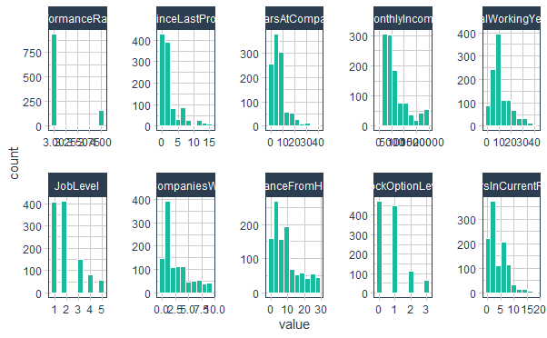

```r
Data_train %>%
    select(skewed_feature_names) %>%
    plot_hist_facet()
```

Ok, it looks like `JobLevel` and `StockOptionLevel` may actually be factors.

```r
#Need to remove 2 of the features
!skewed_feature_names %in% c("JobLevel", "StockOptionLevel")
```

```
 [1]  TRUE  TRUE  TRUE  TRUE  TRUE FALSE  TRUE  TRUE FALSE  TRUE
```

```r
skewed_feature_names <- Data_train %>%
    select_if(is.numeric) %>%
    map_df(PerformanceAnalytics::skewness) %>%
    gather(factor_key = TRUE) %>%
    arrange(desc(value)) %>%
    filter(value >= 0.9) %>% #decided on this number by dropoff to next lowest value and visual inspection of graph
    filter(!key %in% c("JobLevel", "StockOptionLevel")) %>%
    pull(key) %>%
    as.character()
```

```
select_if: dropped 9 variables (Attrition, BusinessTravel, Department, EducationField, Gender, 㠼㸵)
gather: reorganized (EmployeeNumber, Age, DailyRate, DistanceFromHome, Education, 㠼㸵) into (key, value) [was 1x26, now 26x2]
filter: removed 16 rows (62%), 10 rows remaining
filter: removed 2 rows (20%), 8 rows remaining
```

```r
factor_names <- c("JobLevel", "StockOptionLevel")

Levels <- c("0", "1", "2", "3", "4", "5") #setting factor levels up to 5 to match what we saw in the graph of JobLevel and StockOptionLevel
```

```r
#Failed attempts at fixing an error that was caused solely by forgetting to set model to `classification`..? :facepalm:

#Trying to fix the "Outcome must be numeric" error. Mutated Attrition to as.numeric earlier when we changed Travel to an ordered factor. Now instead of Yes and No, it is 1s and 2s. I want to "undo" this as a part of the recipe.

# attritionnums <- c("1", "2")
# attlevels <- c("No", "Yes")

  # step_num2factor(attritionnums,
  #                 transform = function(x) x+1,
  #                 levels = attlevels) #Trying to overcome the "outcome must be numeric" error. Mutated Attrition to Numeric in the Data file, but now want it as Factors for the sake of recipe
```

### Recipe & Workflow creation

Now, we’ll build a recipe that includes the remainder or our data preprocessing steps.

```r
# set.seed(13) Putting seed in the step_upsample arguments

Attrition_rec <-
  recipe(formula = Attrition ~ ., data = Data_train) %>%
  update_role(EmployeeNumber, new_role = "ID") %>% #Don't want EmployeeNumber to be a predictor variable. Keeping it in dataset for convenience of unique ID
  # step_rm(EmployeeNumber) %>% #remove employee ID in case it is f*^king this whole thing up
  step_mutate(JobLevel = factor(JobLevel)) %>%
  step_mutate(StockOptionLevel = factor(StockOptionLevel)) %>%
  themis::step_upsample(all_outcomes(), skip = TRUE, seed = 13) %>% #upsampling to account for unbalance
  step_YeoJohnson(YearsSinceLastPromotion, #Yeo all the numerics
                  #PerformanceRating, #Only 3s and 4s
                  YearsAtCompany,
                  MonthlyIncome,
                  TotalWorkingYears,
                  NumCompaniesWorked,
                  DistanceFromHome,
                  YearsInCurrentRole,
                  YearsWithCurrManager,
                  PercentSalaryHike) %>%
  step_normalize(all_numeric(), -all_outcomes()) %>%  #Center & scale (normalize) numeric variables
  step_nzv(all_predictors()) %>% #Remove numeric predictors near zero variance. Using "nearzero" here because of table in Kuhn, p.550. This step should/would remove the variables I manually removed earlier in notebook.
  step_dummy(all_nominal_predictors(), -all_outcomes())

# Attrition_prep <- Attrition_rec %>% prep(strings_as_factors = FALSE) --Don't need this, but a nice thing to remember. If our ID column was of type Character rather than numeric/integer, this bit would help remedy

summary(Attrition_rec)
```

| variable | type | role | source |
| --- | --- | --- | --- |
| EmployeeNumber | numeric | ID | original |
| Age | numeric | predictor | original |
| BusinessTravel | nominal | predictor | original |
| DailyRate | numeric | predictor | original |
| Department | nominal | predictor | original |
| DistanceFromHome | numeric | predictor | original |
| Education | numeric | predictor | original |
| EducationField | nominal | predictor | original |
| EmployeeCount | numeric | predictor | original |
| EnvironmentSatisfaction | numeric | predictor | original |

[output cut: 25 more lines]

```r
Attrition_rec
```

```
Data Recipe

Inputs:
```

| role | #variables |
| --- | --- |
| ID | 1 |
| outcome | 1 |
| predictor | 33 |

```
Operations:

Variable mutation for JobLevel
Variable mutation for StockOptionLevel
Up-sampling based on all_outcomes()
Yeo-Johnson transformation on 9 items
Centering and scaling for all_numeric(), -all_outcomes()
Sparse, unbalanced variable filter on all_predictors()
Dummy variables from all_nominal_predictors(), -all_outcomes()
```

Next, we finish the lasso regression `workflow`.

```r
lasso_spec <-
  logistic_reg(penalty = tune(), mixture = 1) %>% #mixture = 1 means Lasso; 0 = Ridge
  set_mode("classification") %>%
  set_engine("glmnet")

lasso_workflow <- workflow() %>%
  add_recipe(Attrition_rec) %>%
  add_model(lasso_spec)

lasso_spec
```

```
Logistic Regression Model Specification (classification)

Main Arguments:
  penalty = tune()
  mixture = 1

Computational engine: glmnet
```

```r
lasso_workflow
```

```
== Workflow ============================================================
Preprocessor: Recipe
Model: logistic_reg()

-- Preprocessor --------------------------------------------------------
7 Recipe Steps

* step_mutate()
* step_mutate()
* step_upsample()
* step_YeoJohnson()
* step_normalize()
* step_nzv()
* step_dummy()

-- Model ---------------------------------------------------------------
Logistic Regression Model Specification (classification)

Main Arguments:
  penalty = tune()
  mixture = 1

Computational engine: glmnet
```

#### Tuning the Model

We started with an open tuning parameter. We’ll now use cross validation to find the best penalty value before finalizing the model.

```r
# penalty_grid <- grid_regular(penalty(range = c(-10, 10)), levels = 50)
# penalty_grid

#I don't really understand how to choose a range, but I know we should start large-ish and hone in. So starting with a -10to10 range.

penalty_grid <- grid_regular(penalty(range = c(-3, 3)), levels = 50)
penalty_grid
```

| penalty |
| --- |
| 1.000000e-03 |
| 1.325711e-03 |
| 1.757511e-03 |
| 2.329952e-03 |
| 3.088844e-03 |
| 4.094915e-03 |
| 5.428675e-03 |
| 7.196857e-03 |
| 9.540955e-03 |
| 1.264855e-02 |

[output cut: 40 more lines]

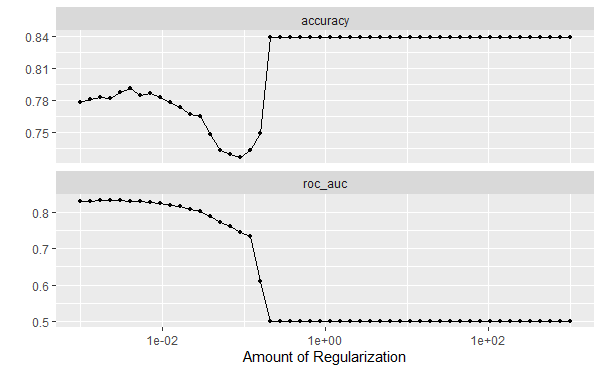

```r
tune_res <- tune_grid(
  lasso_workflow,
  resamples = cv_folds,
  grid = penalty_grid
)
autoplot(tune_res)
```

A second way to visualize, just a little prettier.

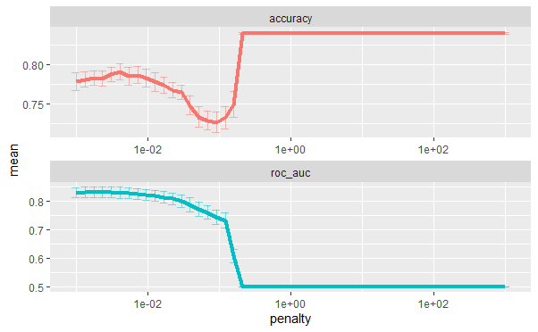

```r
tune_res %>%
  collect_metrics() %>%
  ggplot(aes(penalty, mean, color = .metric)) +
  geom_errorbar(aes(
    ymin = mean - std_err,
    ymax = mean + std_err
  ),
  alpha = 0.5
  ) +
  geom_line(size = 1.5) +
  facet_wrap(~.metric, scales = "free", nrow = 2) +
  scale_x_log10() +
  theme(legend.position = "none")
```

```r
collect_metrics(tune_res)
```

| penalty | .metric | .estimator | mean | n | std_err | .config |
| --- | --- | --- | --- | --- | --- | --- |
| 1.000000e-03 | accuracy | binary | 0.7783349 | 10 | 0.010900007 | Preprocessor1_Model01 |
| 1.000000e-03 | roc_auc | binary | 0.8303065 | 10 | 0.018433451 | Preprocessor1_Model01 |
| 1.325711e-03 | accuracy | binary | 0.7810540 | 10 | 0.009791562 | Preprocessor1_Model02 |
| 1.325711e-03 | roc_auc | binary | 0.8307941 | 10 | 0.018400606 | Preprocessor1_Model02 |
| 1.757511e-03 | accuracy | binary | 0.7828722 | 10 | 0.009208520 | Preprocessor1_Model03 |
| 1.757511e-03 | roc_auc | binary | 0.8312290 | 10 | 0.018292661 | Preprocessor1_Model03 |
| 2.329952e-03 | accuracy | binary | 0.7819713 | 10 | 0.009718230 | Preprocessor1_Model04 |
| 2.329952e-03 | roc_auc | binary | 0.8311212 | 10 | 0.018170871 | Preprocessor1_Model04 |
| 3.088844e-03 | accuracy | binary | 0.7873848 | 10 | 0.009258687 | Preprocessor1_Model05 |
| 3.088844e-03 | roc_auc | binary | 0.8315965 | 10 | 0.018677544 | Preprocessor1_Model05 |

[output cut: 90 more lines]

```r
best_penalty <- select_best(tune_res, metric = "accuracy")
best_penalty
```

| penalty | .config |
| --- | --- |
| 0.2120951 | Preprocessor1_Model20 |

```r
best_penalty_roc <- select_best(tune_res, metric = "roc_auc")
best_penalty_roc
```

| penalty | .config |
| --- | --- |
| 0.003088844 | Preprocessor1_Model05 |

### Fit the Model

```r
lasso_fit <- parsnip::fit(lasso_workflow, data = Data_train)

lasso_fit
```

```r
lasso_final <- finalize_workflow(lasso_workflow, best_penalty)

lasso_final_fit <- parsnip::fit(lasso_final, data = Data_train)

lasso_final_fit
```

```
== Workflow [trained] ==================================================
Preprocessor: Recipe
Model: logistic_reg()

-- Preprocessor --------------------------------------------------------
7 Recipe Steps

* step_mutate()
* step_mutate()
* step_upsample()
* step_YeoJohnson()
* step_normalize()
* step_nzv()
* step_dummy()

-- Model ---------------------------------------------------------------

Call:  glmnet::glmnet(x = maybe_matrix(x), y = y, family = "binomial",      alpha = ~1)

   Df  %Dev   Lambda
1   0  0.00 0.170100
2   1  1.42 0.155000
3   1  2.60 0.141200
4   1  3.58 0.128700
5   2  4.85 0.117300
6   3  6.45 0.106800
7   4  8.04 0.097350
8   6  9.63 0.088700
9   9 11.23 0.080820
10  9 12.95 0.073640
11  9 14.41 0.067100
12 10 15.72 0.061140
13 11 16.96 0.055710
14 14 18.26 0.050760
15 16 19.70 0.046250
16 18 21.15 0.042140
17 19 22.56 0.038400
18 20 23.87 0.034980
19 22 25.10 0.031880
20 24 26.34 0.029050
```

[output cut: 14 more lines]

```
35 37 36.43 0.007195
36 38 36.75 0.006556
37 38 37.02 0.005973
38 39 37.34 0.005443
39 40 37.63 0.004959
40 41 37.88 0.004518
41 41 38.10 0.004117
42 41 38.28 0.003751
43 41 38.44 0.003418
44 41 38.58 0.003114
45 41 38.69 0.002838
46 40 38.79 0.002586

...
and 44 more lines.
```

```r
# lasso_final_fit$fit
```

```
mutate: converted 'Variable' from character to factor (0 new NA)
```

[figure not shown]

```r
library(vip)

lasso_final_fit %>%
  parsnip::fit(Data_train) %>%
  pull_workflow_fit() %>%
  vip::vi(lambda = best_penalty$penalty) %>%
  mutate(
    Importance = abs(Importance),
    Variable = forcats::fct_reorder(Variable, Importance)
  ) %>%
  ggplot(aes(x = Importance, y = Variable, fill = Sign)) +
  geom_col() +
  scale_x_continuous(expand = c(0, 0)) +
  labs(y = NULL)
```

### Cross-Validation

```r
set.seed(13)
#Fit with formula and model
fit_resamples(
  lasso_workflow,
  model = lasso_spec,
  resamples = cv_folds
)
```

[output not shown]

```
# Resampling results
# 10-fold cross-validation using stratification
```

| splits | id | .metrics | .notes |
| --- | --- | --- | --- |
|  | Fold01 |  |  |
|  | Fold02 |  |  |
|  | Fold03 |  |  |
|  | Fold04 |  |  |
|  | Fold05 |  |  |
|  | Fold06 |  |  |
|  | Fold07 |  |  |
|  | Fold08 |  |  |
|  | Fold09 |  |  |
|  | Fold10 |  |  |

```r
set.seed(13)

fit_resamples(lasso_workflow,
              lasso_spec,
              resamples = cv_folds) %>%
  collect_metrics()
```

[output not shown]